# Engineering Test - Modeling

**Author**: Mawuli Adjei

**Date**: 5/10/2020

### Objective

The objective of this exercise is to build a model that can determine if a scene has a desired feature in it. Essentially, this model will be built to classify if a given scene with all it's features and characteristics provided, contains a desired feature through inference.

To begin with, the feture that will be modeled for is: **h_food_str**. This variable in the dataset provided is a flag for whether food is present in a scene of the TV show episodes provided.

### Methodology

1. Data Exploration
   1. Output Class (Food) Distribution
   2. Time - Output Class Relationships
      1. Feature Engineering
   3. Exploration of Correlation
2. Data Preprocessing
3. Modeling
   1. Benchmark Models
   2. Benchmark Model Evaluations
   3. Hyper Parameter Tuning
   4. Final Models and Evalaution Metrics

```python
#import needed packages for reading data and initial exploration
```

```python
import pandas as pd
import numpy as np
import seaborn as sns
import matplotlib.pyplot as plt
import warnings
warnings.filterwarnings("ignore")
```

```python
data = pd.read_csv('Technical Task Dataset.csv')
```

```python
data.head()
```

|  | show_name | time_offset | r_abies | r_abyssinian | r_accessories | r_accipiter | r_acorn | r_adapter | r_adorable | r_adventure | ... | r_yak | r_yard | r_yew | r_zebra | r_zebra_crossing | r_zoo | h_alcohol_str | h_food_str | h_hot_drink_str | h_phone_str |
| --- | --- | --- | --- | --- | --- | --- | --- | --- | --- | --- | --- | --- | --- | --- | --- | --- | --- | --- | --- | --- | --- |
| 0 | fresh_meat | 1 | 0.0 | 0.0 | 0.0 | 0.0 | 0.0 | 0.0 | 0.0 | 0.0 | ... | 0 | 0.0 | 0.540910 | 0.0 | 0.0 | 0.0 | 0 | 0 | 0 | 0 |
| 1 | fresh_meat | 2 | 0.0 | 0.0 | 0.0 | 0.0 | 0.0 | 0.0 | 0.0 | 0.0 | ... | 0 | 0.0 | 0.515789 | 0.0 | 0.0 | 0.0 | 0 | 0 | 0 | 0 |
| 2 | fresh_meat | 3 | 0.0 | 0.0 | 0.0 | 0.0 | 0.0 | 0.0 | 0.0 | 0.0 | ... | 0 | 0.0 | 0.527750 | 0.0 | 0.0 | 0.0 | 0 | 0 | 0 | 0 |
| 3 | fresh_meat | 4 | 0.0 | 0.0 | 0.0 | 0.0 | 0.0 | 0.0 | 0.0 | 0.0 | ... | 0 | 0.0 | 0.534361 | 0.0 | 0.0 | 0.0 | 0 | 0 | 0 | 0 |
| 4 | fresh_meat | 5 | 0.0 | 0.0 | 0.0 | 0.0 | 0.0 | 0.0 | 0.0 | 0.0 | ... | 0 | 0.0 | 0.529979 | 0.0 | 0.0 | 0.0 | 0 | 0 | 0 | 0 |

5 rows × 1610 columns

```python
data.info()
```

```
<class 'pandas.core.frame.DataFrame'>
RangeIndex: 16568 entries, 0 to 16567
Columns: 1610 entries, show_name to h_phone_str
dtypes: float64(1439), int64(170), object(1)
memory usage: 203.5+ MB
```

```python
data.shape
```

```
(16568, 1610)
```

## Data Exploration

```python
#show the different shows that are covered in the data set and how much each contributed to the size of the dataset
data.show_name.value_counts(sort = True)
```

```
made_in_chelsea        2884
my_mad_fat_diary       2879
made_in_chelsea_la     2813
fresh_meat             2459
friday_night_dinner    1438
hollyoaks              1400
peep_show              1384
the_inbetweeners       1311
Name: show_name, dtype: int64
```

From this, we see that some episodes in the dataset run for much longer than others. While, this intuitively does not suggest any direct implication on our ability to build our classification models, it does give us a hint that we have to be careful when using any time related variables.

### Output Label Exploration:

From the outputs we see below, there is a very clear class imbalance. Meaning that of the two labels (0 or 1) indicating whether food is present in the scene or not, we have more times where 0 appears. Simply put, 91.1% of the scenes in the dataset do not have food showing in them.

This poses a challenge because we have to ensure that the models we build deal with the inherent bias that comes with an imbalanced output class distribution.

It also suggests that a mere accuracy metric will not suffice when evaluating the models built.

```python
#show number of data points per label
data.h_food_str.value_counts()
```

```
0    15104
1     1464
Name: h_food_str, dtype: int64
```

```python
#show percentage distribution of data points per label
data.h_food_str.value_counts(normalize=True)
```

```
0    0.911637
1    0.088363
Name: h_food_str, dtype: float64
```

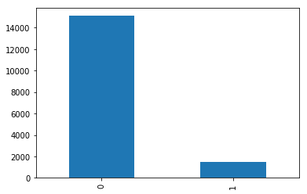

```python
#visualize class imbalance
data.h_food_str.value_counts().plot.bar()
```

### Output Label Further Exploration:

From the outputs we see above, each show has a distinctly different class distribution. This immediately suggests that each show has a different relationship with the output variable; food.

This suggests that the show would be a significant variable in modeling whether a scene has food in it or not.

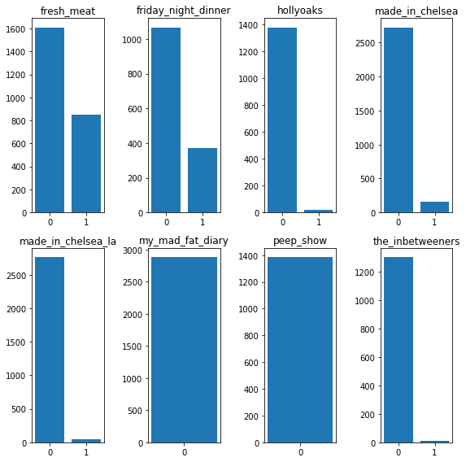

```python
count = 1
plt.figure(figsize=(8,8))
for i in data.show_name.unique():
    plt.subplot(2,4,count)
    plt.bar(data[data.show_name == i].h_food_str.unique().astype('str'),data[data.show_name == i].h_food_str.value_counts())
    plt.title(i)
    count+=1
plt.tight_layout()
plt.show()
```

### Time Offset Variable Exploration:

The dataset contains more than 1000 different variables outputed from AWS rekognition. These variables may be difficult to glean insights from due to the fact that they are sparse and computer generated. However, we can turn our attention to the time offset variable, which is directly from and inherent to the show itself.

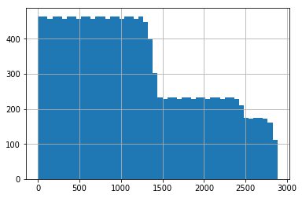

```python
data.time_offset.hist(bins = 50)
```

By looking at the distribution of the *Time Offset* variable against the labels we are trying to predict, we see clear relationships between the time of an episode and when food occurs. We see that we have peaks in food related scenes around the first 100 seconds, between the 600 seconds and 800 seconds and the around 1700 seconds into an episode.

This relationship shows that for the shows that have scenes with food in them, the food tends to come at specific times.

However, as we detailed out earlier, we have to be careful when modeling based on this variable because we may end up introducing unwanted bias due to the fact that not all shows have the same length. This suggests to us that we would have to perform some feature engineering to transform this variable into a more robust one later.

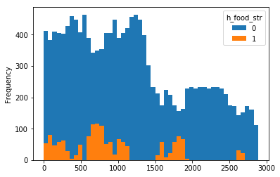

```python
data.pivot(columns="h_food_str", values="time_offset").plot.hist(bins=50)
```

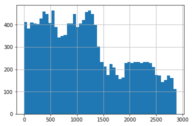

```python
#plot distribution of time offset variable for rows where food is not present in the scene
data[data.h_food_str==0].time_offset.hist(bins = 50)
```

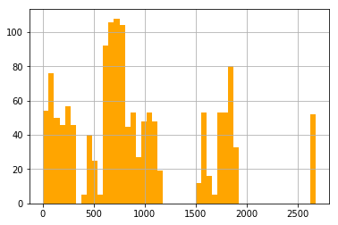

```python
#plot distribution of time offset variable for rows where food is present in the scene
data[data.h_food_str==1].time_offset.hist(bins = 50, color='orange')
```

#### Feature Engineering - Time Offset Variable:

As we have seen earlier, not all episodes have the same length. As such, in order to properly use the *time_offset* variable, we have to consider normalizing it for each show. Such that rather than using the number of seconds from the start of the show, we would use the percentage of the episode that has elapsed up till any given point.

This new variable can easily be expressed by:

Time Offset / Episode Length

```python
#Find values to create the normalized time_offset var
max_values = pd.DataFrame(data.show_name.value_counts()).reset_index()
max_values.columns = np.array(['show_name','episode_length'])
data = data.merge(max_values, how='left', on='show_name')
```

```python
#new variable elapsed created to represent percentage of each episode that has been completed
data['elapsed'] = data.time_offset/data.episode_length
```

```python
#checking to see if elapsed is at 100% only at the end of the episode
data[data.elapsed == 1][['show_name','time_offset','episode_length','elapsed']]
```

|  | show_name | time_offset | episode_length | elapsed |
| --- | --- | --- | --- | --- |
| 2458 | fresh_meat | 2459 | 2459 | 1.0 |
| 3896 | friday_night_dinner | 1438 | 1438 | 1.0 |
| 5296 | hollyoaks | 1400 | 1400 | 1.0 |
| 8180 | made_in_chelsea | 2884 | 2884 | 1.0 |
| 10993 | made_in_chelsea_la | 2813 | 2813 | 1.0 |
| 13872 | my_mad_fat_diary | 2879 | 2879 | 1.0 |
| 15256 | peep_show | 1384 | 1384 | 1.0 |
| 16567 | the_inbetweeners | 1311 | 1311 | 1.0 |

We can proceed to examine the distribution of the new time related variable and the relationships that exist with it and our target variable

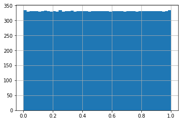

```python
data.elapsed.hist(bins = 50)
```

As expected the distribution of the new variable; *elapsed* is uniform between 0 and 1 in the graph above.

We can follow this up by looking at the distribution of *elapsed* broken down by the target variable.

As we see below, the distribution in terms of our target label food gives a fairer picture to draw from regardless of the episode length.

From this, we see that the distribution is largely similar, however, it's more interpretable on a population basis. We can tell that in the first 15% of any episode, the likelihood seeing a scene with food in it is higher than normal. This also applies to the following bands:

```
        22% - 58%,
        62% - 78%,
        96% (a small peak)
```

This gives us good confidence to use this new variable *elapsed* to model rather than the initial *time_offset* variable

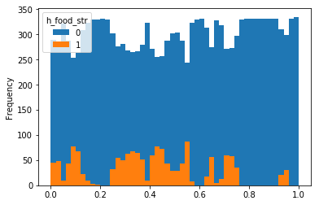

```python
data.pivot(columns="h_food_str", values="elapsed").plot.hist(bins=50)
```

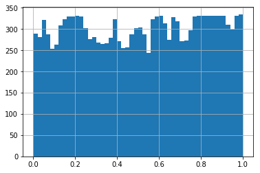

```python
#plot distribution of time offset variable for rows where food is not present in the scene

data[data.h_food_str==0].elapsed.hist(bins = 50)
```

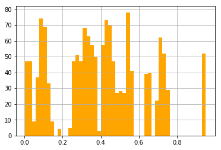

```python
#plot distribution of time offset variable for rows where food is present in the scene

data[data.h_food_str==1].elapsed.hist(bins = 50, color='orange')
```

## Preprocessing

### Train and Test Split

To do this properly, we have to control for bias coming from the information concerning the tv show, and the time of each episode

This means we would have to make sure the representation of each show in the training and the test sets have the same distribution as they would in the overall population.

This also means we would have to randomize the times in which we are predicting whether there is a food column or not. This will do away with any inherent bias that may lie in the sequence of the scenes in each tv show.

```python
from sklearn.model_selection import train_test_split as tts
```

```python
#group data by show and label. After, draw a random sample from each group to be the test set.
grouped = data.groupby(['show_name','h_food_str'])
test_set=grouped.apply(lambda x: x.sample(frac=0.33, replace=False, random_state = 42)).drop(['show_name','h_food_str'], axis =1).reset_index().drop('level_2', axis = 1)
```

```python
#filter out test set from population to derive training set
train_set = data.merge(test_set[['show_name', 'time_offset']], on=['show_name', 'time_offset'], indicator=True, how='left').loc[lambda x : x['_merge']!='both'].drop('_merge', axis=1)
```

```python
train_set.shape
```

```
(11101, 1612)
```

```python
test_set.shape
```

```
(5467, 1612)
```

```python
data.shape[0]-test_set.shape[0]
```

```
11101
```

### Hot One Encoding

As mentioned earlier, each shows have some unique relationships with the target variable. As such it might be desirable to include the TV show in the data.

To do this, we have to convert this variable into information that can be understood by the model through one hot encoding.

```python
train = pd.get_dummies(train_set)
test = pd.get_dummies(test_set)
```

### Create Filter for Unnecessary Variables

This will be used to filter out variables we wouldnt want to model with later on.

These variables are:

1. show_name (this is not understandable by the model in its form)
2. time_offset (we have engineered the *elapsed* variable to replace this)
3. episode_length (we created this variables as a preliminary step in deriving the elapsed variable)
4. h_food_str (we wouldn't want to include this variable in our modeling else we would not be able to fairly infer the target

```python
rm_cols = ['show_name','time_offset','episode_length','h_food_str']
```

## Modelling

With the insights and new features from our data exploration, and the preprocessed data, we can proceed to model our data to infer which scenes have food in them.

The modeling algorithm of choice in this case is gradient boosting.

This was chosen because:

1. Gradient Boosting performs well when the size of the data is large
2. It handles both linear and non-linear relationships well. This is important because due to the data size and limited time for modeling, linear models (logistic regression) are not expected to perform well.
3. It handles multicolinearity well
4. It inherently performs feature selection due to it's tree based structure
5. Interpretability

The Light Gradient Boosting Implementation of gradient boosting was chosen for its training efficiency without any significant loss in accuracy compared to XGBoost. It also has inbuilt means of dealing with unbalanced datasets

```python
#import modeling algo
import lightgbm as lgb
```

```python
#import model evaluation criteria
from sklearn.metrics import confusion_matrix as cx
from sklearn.metrics import accuracy_score as acc
from sklearn.metrics import f1_score as f1
```

### Baseline Models

We will be building two baseline models with minimal parameters and intervention. One will be built using all the variables and the second will be built without the information concerning the TV_Shows. This will allow us to confirm our initial assumption that each TV show has a unique relationship with the output variable. Our expectation is that the model with the TV Show variable will perform better.

After our baseline models, we can proceed to consider more improvements to our model.

#### First Model with TV show variable

```python
#initialize model
model = lgb.LGBMClassifier(objective='binary',is_unbalanced = True)
```

```python
model.fit(train[train.columns.difference(rm_cols)], train.h_food_str, eval_metric='binary_logloss')
```

```
LGBMClassifier(boosting_type='gbdt', class_weight=None, colsample_bytree=1.0,
               importance_type='split', is_unbalanced=True, learning_rate=0.1,
               max_depth=-1, min_child_samples=20, min_child_weight=0.001,
               min_split_gain=0.0, n_estimators=100, n_jobs=-1, num_leaves=31,
               objective='binary', random_state=None, reg_alpha=0.0,
               reg_lambda=0.0, silent=True, subsample=1.0,
               subsample_for_bin=200000, subsample_freq=0)
```

```python
probs = model.predict_proba(test[test.columns.difference(rm_cols)])
```

### Model Evaluation

Our model evaluation will look at the following metrics.

1. Accuracy
2. F1 Score and Confusion Matrices
3. Auroc

Our key metric will be the F1 Score. This is due to the imbalanced nature of the dataset. Our imbalanced dataset implies, as we will see, that we can achieve a very high accuracy score by just predicting that there is no scene with food in it in the dataset. This makes the F1 score a better metric because it considers the false predictions as well as the correct predictions. Meaning that we need to correctly predict both classes to get a good F1 score.

### Benchmark Metrics

Before evaluating our baseline models, we need to set benchmarks to help us determine whether our the metrics we see on our baseline models are good or not.

To do this, we look at what the F1 score and the accuracy score would be in the hypothetical case where we only predict that there are no scenes with food in it.

Our benchmark scores, as seen below are:

1. Accuracy: 91.18%
2. F1: 0.0041

This shows the relevance of using F1 score, since the accuracy metric is clearly misleading with a high accuracy score but an F1 score that is practically 0.

```python
accuracy = acc(test.h_food_str, ([0]*len(test.h_food_str)))
f1_score = f1(test.h_food_str, (([0]*(len(test.h_food_str)-1))+[1]))
```

```python
print('Benchmark accuracy is:', str((round(accuracy, 4)*100))+'%', '\n', 'Benchmark F1 score is:', (round(f1_score, 4)))
```

```
Benchmark accuracy is: 91.18%
 Benchmark F1 score is: 0.0041
```

### Custom Evaluation Functions

As a final step to properly evaluate the baseline models, I have built custom functions that would help us visualize and optimize our evaluation processes.

1. plot_metrics function: This allows us to choose an optimal cutoff point for converting our label probabilities into actual labels. This is *extremely* important to do since it's the best way to extract the full predictive power from our models.
2. show_auroc function: This allows us to see the AUROC score
3. show_confusion function: This allows us to see the confusion matrix that summarizes our predictions

```python
def plot_metrics(test_lab1, pred_probs):
    from sklearn.metrics import confusion_matrix as cx
    from sklearn.metrics import accuracy_score as acc
    from sklearn.metrics import f1_score as f1
    bal_ = []
    fn_ = []
    fp_ = []
    f1_ = []
    agg_ = []
    acc_ = []
    for i in np.linspace(0.1, 0.9, 100):
        pred_1 = np.where(pred_probs[:,1] > i, 1, 0)
        acc_.append(acc(test_lab1, pred_1))
        f1_.append(f1(test_lab1, pred_1))
        bal_.append(abs((cx(test_lab1, pred_1).ravel()[1]-(cx(test_lab1, pred_1).ravel()[2]))))
        agg_.append(abs((cx(test_lab1, pred_1).ravel()[1]+(cx(test_lab1, pred_1).ravel()[2]))))
        fp_.append(cx(test_lab1, pred_1).ravel()[1])
        fn_.append(cx(test_lab1, pred_1).ravel()[2])

    plt.figure(figsize=(7,7))
    plt.plot(np.linspace(0.1, 0.9, 100), acc_, 'r-', label = 'accuracy')
    plt.plot(np.linspace(0.1, 0.9, 100), f1_, 'b-', label = 'F1 Score')
    plt.legend(loc='upper left')
    plt.show()
    plt.figure(figsize=(7,7))
    plt.plot(np.linspace(0.1, 0.9, 100), bal_, 'g-', label = 'Balance')
    plt.plot(np.linspace(0.1, 0.9, 100), agg_, 'y-', label = 'Aggregate of False Predictions')
    plt.plot(np.linspace(0.1, 0.9, 100), fn_, 'r-', label = 'False Negatives')
    plt.plot(np.linspace(0.1, 0.9, 100), fp_, 'b-', label = 'False Postives')
    plt.legend(loc='upper left')
    plt.show()

    print('The highest F1 score;', max(f1_), 'occurs at a cut off probability of:',\
          np.linspace(0.1, 0.9, 100)[f1_.index(max(f1_))])
    print('The best balance;', min(bal_), 'occurs at a cut off probability of:',\
          np.linspace(0.1, 0.9, 100)[bal_.index(min(bal_))])
```

```python
def show_auroc(actual_outcome, predicted_outcome):
    from sklearn import metrics
    fpr, tpr, thresholds = metrics.roc_curve(actual_outcome, predicted_outcome)
    return metrics.auc(fpr, tpr)

def show_confusion(actual_outcome, predicted_outcome):
    from sklearn.metrics import confusion_matrix as cx
    return cx(actual_outcome, predicted_outcome)
```

### Evaluation: Baseline Model

By using the plot_metrics function, we are able to see that the optimal cut off point to maxmimize the F1 score is at **0.253**

At this point, we are also able to lower the total number of false predictions without trading one type of false prediction off for another. ie We are able to balance the number of false positives with the false negatives.

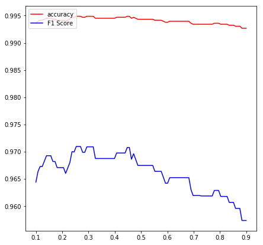

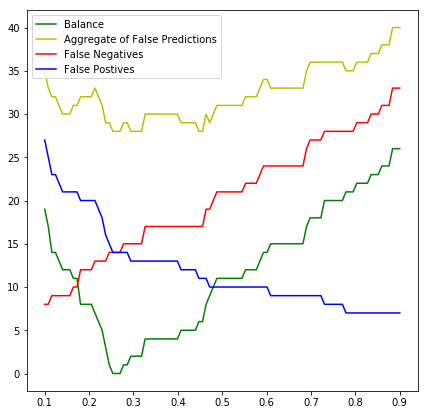

```
The highest F1 score; 0.970954356846473 occurs at a cut off probability of: 0.2535353535353535
The best balance; 0 occurs at a cut off probability of: 0.2535353535353535
```

```python
plot_metrics(test.h_food_str, probs)
```

```python
test_predictions = np.where(probs[:,1] > 0.2535353535353535, 1, 0)
```

```python
final_accuracy = acc(test.h_food_str, test_predictions)
final_f1 = f1(test.h_food_str, test_predictions)
```

After applying the cut off point, we have our final accuracy metrics for the baseline model with the TV show variable.

Our metrics are as follows:

1. Accuracy: 99.49%
2. F1 Score: 0.971
3. AUROC: 0.98
4. Our confusion matrix shows a very low false prediction rate

```python
print('Accuracy of Baseline Model:', str(round(final_accuracy, 4))+'%')
print('F! score of Baseline Model:', round(final_f1, 4))
```

```
Accuracy of Baseline Model: 0.9949%
F! score of Baseline Model: 0.971
```

```python
show_auroc(test.h_food_str, test_predictions)
```

```
0.9840729657853228
```

```python
show_confusion(test.h_food_str, test_predictions)
```

```
array([[4971,   14],
       [  14,  468]])
```

#### Interpretation

Based on the fitted model, we can look at the influence of each variable on our predictions.

The importance of a variable is determined by the number of times splits in the tree are done based on that feature. Looking at the top 30 variables we can glean the following insights:

We see that the *elapsed* variable is the most important one by a long range. This tells us that the food scenes tend to follow a trend and appear at some specific times during shows. ie. As we learned from our exploration, around the start, middle and the end of the episodes.

The show_name variable(s) are also among the most important ones which validates our assumptions about their importance and relationship with the target variable food. It suggests that food factors in the episodes differently.

Also, looking at the other variables, we see that the model is inferring that there is food in the scene by checking whether the scene is indoors, and whether there is cutlery or other dining articles.

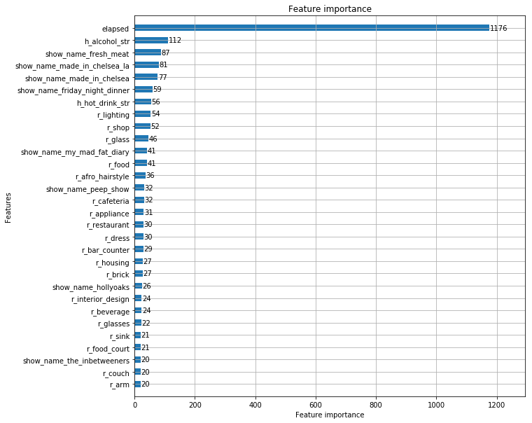

```python
lgb.plot_importance(model,max_num_features=30,ignore_zero=True, height=0.5, figsize=(10,10))
```

#### Baseline Model without TV show variable

Going through the same process as we did for the initial model, we see that the model without the TV show name variables does not perform as well as the model with the variable.

Our metrics are as follows as shown below:

1. Accuracy: 96.7%
2. F1 Score: 0.8022
3. AUROC: 0.87
4. Our confusion matrix shows a very low false prediction rate, albeit much higher than our baseline model with the tv show variable.

#### Baseline Modeling Conclusion

Our baseline model without the TV show variables has only a maximum F1 score of 0.8 even though the accuracy is quite high. This shows that it is possible to model the data and acheive a good score without the TV show variable, so as to be able to maybe generalize the model for other TV shows. However, as compared to our model with the tv show variable, it doesnt perform as well. Given that the task was based on optimizing for advertizing, we probably do not want to treat each episode the same. As such, we can proceed to focus solely on the model with the TV show variable.

```python
rm_cols_ = ['time_offset','episode_length','h_food_str','show_name']
```

```python
model2 = lgb.LGBMClassifier(objective='binary',is_unbalanced = True)
```

```python
model2.fit(train[train_set.columns.difference(rm_cols_)], train_set.h_food_str, eval_metric='binary_logloss')
```

```
LGBMClassifier(boosting_type='gbdt', class_weight=None, colsample_bytree=1.0,
               importance_type='split', is_unbalanced=True, learning_rate=0.1,
               max_depth=-1, min_child_samples=20, min_child_weight=0.001,
               min_split_gain=0.0, n_estimators=100, n_jobs=-1, num_leaves=31,
               objective='binary', random_state=None, reg_alpha=0.0,
               reg_lambda=0.0, silent=True, subsample=1.0,
               subsample_for_bin=200000, subsample_freq=0)
```

```python
probs = model2.predict_proba(test_set[test_set.columns.difference(rm_cols_)])
```

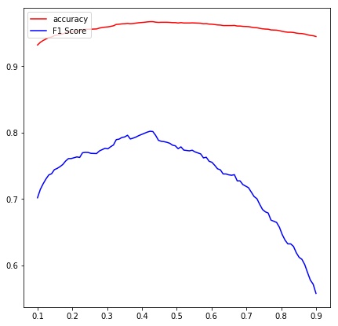

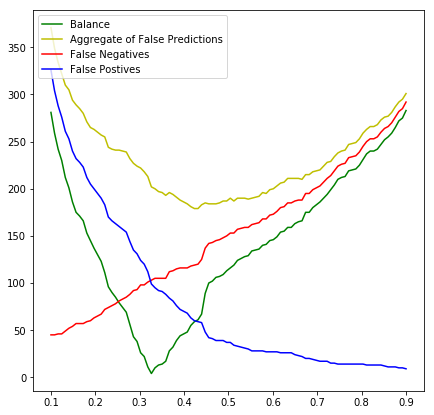

```
The highest F1 score; 0.8022099447513813 occurs at a cut off probability of: 0.4232323232323232
The best balance; 4 occurs at a cut off probability of: 0.32626262626262625
```

```python
plot_metrics(test_set.h_food_str, probs)
```

```python
test_predictions = np.where(probs[:,1] > 0.4232323232323232, 1, 0)
```

```python
final_accuracy = acc(test.h_food_str, test_predictions)
final_f1 = f1(test.h_food_str, test_predictions)
```

```python
print('Accuracy of Baseline Model:', str(round(final_accuracy, 4))+'%')
print('F! score of Baseline Model:', round(final_f1, 4))
```

```
Accuracy of Baseline Model: 0.9673%
F! score of Baseline Model: 0.8022
```

```python
show_auroc(test.h_food_str, test_predictions)
```

```
0.8705379624350229
```

```python
show_confusion(test.h_food_str, test_predictions)
```

```
array([[4925,   60],
       [ 119,  363]])
```

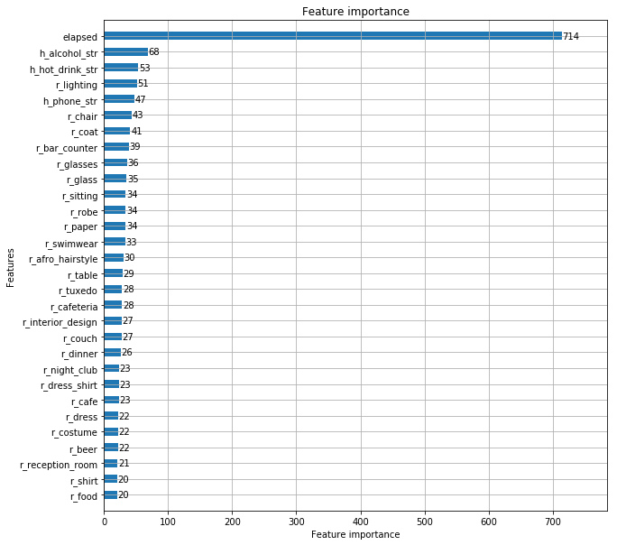

```python
lgb.plot_importance(model2,max_num_features=30,ignore_zero=True, height=0.5, figsize=(10,10))
```

### Model Improvements

Based off the success of our baseline model with the tv show variable, we proceed to fine tune the model to take it closer to perfection.

To do this, I built a custom hyper parameter tuning function in order to have more control over the process.

#### Hyperparameter Tuning: Learning Rate

We see that we are able to boost the evaluation metrics by setting the learning rate at 0.282

Our new metrics are as follows as seen below:

```python
def model_function(train, test, rm_cols,param):
    model = lgb.LGBMClassifier(objective='binary',is_unbalanced = True, learning_rate=param)
    model.fit(train[train.columns.difference(rm_cols)], train.h_food_str, eval_metric='binary_logloss')
    probs = model.predict_proba(test[test.columns.difference(rm_cols)])

    f1_ = []
    acc_ = []
    for i in np.linspace(0.1, 0.9, 100):
        pred_1 = np.where(probs[:,1] > i, 1, 0)
        acc_.append(acc(test.h_food_str, pred_1))
        f1_.append(f1(test.h_food_str, pred_1))

    cut_off = np.linspace(0.1, 0.9, 100)[f1_.index(max(f1_))]
    test_predictions = np.where(probs[:,1] > cut_off, 1, 0)
    accuracy_score = acc(test.h_food_str, test_predictions)
    f1_score = f1(test.h_food_str, test_predictions)
    return [accuracy_score, f1_score]
```

```python
learning_rate_param = np.linspace(0.01, 0.6,40)
iter_accuracy = list()
iter_f1 = list()
```

```python
for i in learning_rate_param:
    metrics = model_function(train, test, rm_cols, i)
    iter_accuracy.append(metrics[0])
    iter_f1.append(metrics[1])
```

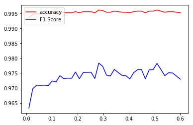

```python
plt.plot(learning_rate_param, iter_accuracy, 'r-', label = 'accuracy')
plt.plot(learning_rate_param, iter_f1, 'b-', label = 'F1 Score')
plt.legend(loc='upper left')
plt.show()
```

```python
optimal_learning_rate = learning_rate_param[iter_f1.index(max(iter_f1))]
```

```python
print('The optimal learning rate is:', round(optimal_learning_rate,3))
print('We achieve a further boost in F1 and Accuracy to:',
      round(max(iter_f1),4), 'and',
      str(round(iter_accuracy[iter_f1.index(max(iter_f1))], 4))+'%', 'respectively')
```

```
The optimal learning rate is: 0.282
We achieve a further boost in F1 and Accuracy to: 0.9784 and 0.9962% respectively
```

#### Hyperparameter Tuning: Subsample Ratio

Tuning the Subsample Ratio did not have any effect on the performance of the model. As such, we continue without considering it.

```python
def model_function(train, test, rm_cols,param):
    model = lgb.LGBMClassifier(objective='binary',is_unbalanced = True, learning_rate=0.282, subsample=param)
    model.fit(train[train.columns.difference(rm_cols)], train.h_food_str, eval_metric='binary_logloss')
    probs = model.predict_proba(test[test.columns.difference(rm_cols)])

    f1_ = []
    acc_ = []
    for i in np.linspace(0.1, 0.9, 100):
        pred_1 = np.where(probs[:,1] > i, 1, 0)
        acc_.append(acc(test.h_food_str, pred_1))
        f1_.append(f1(test.h_food_str, pred_1))

    cut_off = np.linspace(0.1, 0.9, 100)[f1_.index(max(f1_))]
    test_predictions = np.where(probs[:,1] > cut_off, 1, 0)
    accuracy_score = acc(test.h_food_str, test_predictions)
    f1_score = f1(test.h_food_str, test_predictions)
    return [accuracy_score, f1_score]
```

```python
subsample_param = np.linspace(0.01, 1,20)
iter_accuracy = list()
iter_f1 = list()
```

```python
for i in subsample_param:
    metrics = model_function(train, test, rm_cols, i)
    iter_accuracy.append(metrics[0])
    iter_f1.append(metrics[1])
```

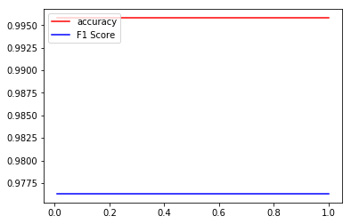

```python
plt.plot(subsample_param, iter_accuracy, 'r-', label = 'accuracy')
plt.plot(subsample_param, iter_f1, 'b-', label = 'F1 Score')
plt.legend(loc='upper left')
plt.show()
```

```python
optimal_subsample = subsample_param[iter_f1.index(max(iter_f1))]
```

```python
print('The optimal subsample ratio is:', round(optimal_subsample,3))
print('We achieve a further boost in F1 and Accuracy to:',
      round(max(iter_f1),4), 'and',
      str(round(iter_accuracy[iter_f1.index(max(iter_f1))], 4))+'%','respectively')
```

```
The optimal subsample ratio is: 0.01
We achieve a further boost in F1 and Accuracy to: 0.9763 and 0.9958% respectively
```

```python
def model_function(train, test, rm_cols,param):
    model = lgb.LGBMClassifier(objective='binary',is_unbalanced = True, learning_rate=0.282, reg_alpha=param)
    model.fit(train[train.columns.difference(rm_cols)], train.h_food_str, eval_metric='binary_logloss')
    probs = model.predict_proba(test[test.columns.difference(rm_cols)])

    f1_ = []
    acc_ = []
    for i in np.linspace(0.1, 0.9, 100):
        pred_1 = np.where(probs[:,1] > i, 1, 0)
        acc_.append(acc(test.h_food_str, pred_1))
        f1_.append(f1(test.h_food_str, pred_1))

    cut_off = np.linspace(0.1, 0.9, 100)[f1_.index(max(f1_))]
    test_predictions = np.where(probs[:,1] > cut_off, 1, 0)
    accuracy_score = acc(test.h_food_str, test_predictions)
    f1_score = f1(test.h_food_str, test_predictions)
    return [accuracy_score, f1_score]
```

```python
ridge_param = np.linspace(0.01, 1,20)
iter_accuracy = list()
iter_f1 = list()
```

```python
for i in ridge_param:
    metrics = model_function(train, test, rm_cols, i)
    iter_accuracy.append(metrics[0])
    iter_f1.append(metrics[1])
```

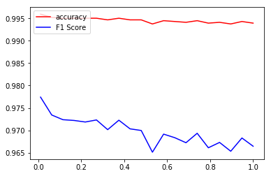

```python
plt.plot(ridge_param, iter_accuracy, 'r-', label = 'accuracy')
plt.plot(ridge_param, iter_f1, 'b-', label = 'F1 Score')
plt.legend(loc='upper left')
plt.show()
```

```python
optimal_ridge = ridge_param[iter_f1.index(max(iter_f1))]
```

```python
print('The ridge regularization value  subsample ratio is:', round(optimal_ridge,3))
print('We achieve a further boost in F1 and Accuracy to:',
      round(max(iter_f1),4), 'and',
      str(round(iter_accuracy[iter_f1.index(max(iter_f1))], 4))+'%','respectively')
```

```
The ridge regularization value  subsample ratio is: 0.01
We achieve a further boost in F1 and Accuracy to: 0.9774 and 0.996% respectively
```

## Final Model

Given that we have chosen our model, and tuned it with the learning rate parameter, we can proceed to build our finalized model with data containing the tv show variable.

We are able to build a model that scores the following evaluation:

Our feature importances tell us the same story from earlier, which shows robustness of the model even with the hyperparameter tuning.

```python
model = lgb.LGBMClassifier(objective='binary',is_unbalanced = True,learning_rate=0.282)
```

```python
model.fit(train[train.columns.difference(rm_cols)], train.h_food_str, eval_metric='binary_logloss')
```

```
LGBMClassifier(boosting_type='gbdt', class_weight=None, colsample_bytree=1.0,
               importance_type='split', is_unbalanced=True, learning_rate=0.282,
               max_depth=-1, min_child_samples=20, min_child_weight=0.001,
               min_split_gain=0.0, n_estimators=100, n_jobs=-1, num_leaves=31,
               objective='binary', random_state=None, reg_alpha=0.0,
               reg_lambda=0.0, silent=True, subsample=1.0,
               subsample_for_bin=200000, subsample_freq=0)
```

```python
probs = model.predict_proba(test[test.columns.difference(rm_cols)])
```

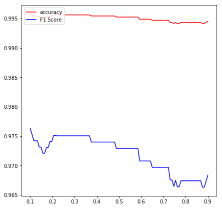

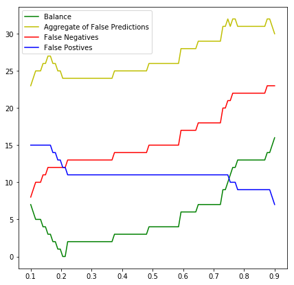

```
The highest F1 score; 0.976313079299691 occurs at a cut off probability of: 0.1
The best balance; 0 occurs at a cut off probability of: 0.20505050505050504
```

```python
plot_metrics(test.h_food_str, probs)
```

```python
test_predictions = np.where(probs[:,1] > 0.1, 1, 0)
```

```python
final_accuracy = acc(test.h_food_str, test_predictions)
final_f1 = f1(test.h_food_str, test_predictions)
```

```python
print('Accuracy of Baseline Model:', str(round(final_accuracy, 4))+'%')
print('F! score of Baseline Model:', round(final_f1, 4))
```

```
Accuracy of Baseline Model: 0.9958%
F! score of Baseline Model: 0.9763
```

```python
show_auroc(test.h_food_str, test_predictions)
```

```
0.9901967312726562
```

```python
show_confusion(test.h_food_str, test_predictions)
```

```
array([[4970,   15],
       [   8,  474]])
```

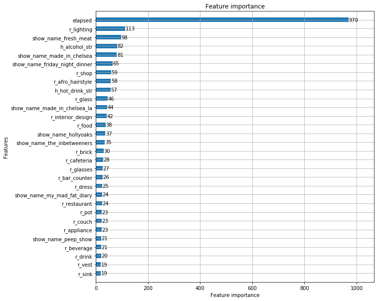

```python
lgb.plot_importance(model,max_num_features=30,ignore_zero=True, height=0.5, figsize=(10,10))
```

## Conclusion

We have seen that is is possible to model the data to be able to accurately infer when a scene in a tv show has food in it or not.

From our data exploration, we learned that the progression of time through a TV episode is actually very useful in determining whether a scene has food in it or not. This shows that tv show producers follow a pattern in placing scenes with food in their shows.

The implication this has is that even without building complex statistical models, we can advise the advertiser on when to show advertising related to food. The best times as seen from the analysis is as follows:

[output not shown]

Moving on to more advanced modeling, we can use gradient boosting methods to model the data into a classifer in order to predict which scenes have food in them to a high degree of accuracy. We reached metrics of 99.5% accuracy and a 0.976 F1 score.

Through this model, we also learned through the feature importances that scenes that have people in them and/or are indoors have higher likelihood of helping us predict whether there is food in a scene or not. This can be seen as variables such as interior design, dress, restaurant, couch, glass, afro hairsytle are in the top 30 variables.